compiled on February 10, 2020

# RchivalTag Package Tutorial

Part 5 - Behavioral metrics

Dr. Robert Bauer | Data Scientist & Fishery Biologist

- 1. Hawai’i Institute of Marine Biology, University of Hawai’i at Mānoa, Kāne’ohe, Hawai’i, United States of America  
     rkbauer@hawaii.edu  
     https://orcid.org/0000-0003-4224-8023

### Principle (Pop-up)-Archival Tagging Data:

1. Read-in functions for different archival tag data products
2. Time-at-Depth (TaD) and Time-at-Temperature (TaT) Histogram data
3. Time series data (e.g. depth and temperature)
4. PAT-style Depth Temperature profiles (PDT) data
5. Tracks (Geolocation Estimates and Likelihood Areas from light levels, depth and temperature)

### Getting started:

```r
## install or load package
# install.packages("RchivalTag")
library("RchivalTag")
## Package overview:
?RchivalTag
help(package="RchivalTag") ## list of functions
```

### Behavioral metrics

Behavioral metrics are an important component of many ecological model approaches such as habitat models or behavior models. The choice of a suitable metric depends on the research question (e.g. the percentage of time spent in a specific depth layer (Bauer et al. 2017, 2020), or the average depth preferences). However, in many cases, the data availability limits this choice. This concerns in particular pop-up archival tags with often limited transmission capacities.

#### How to get behavioral metrics from histogram data:

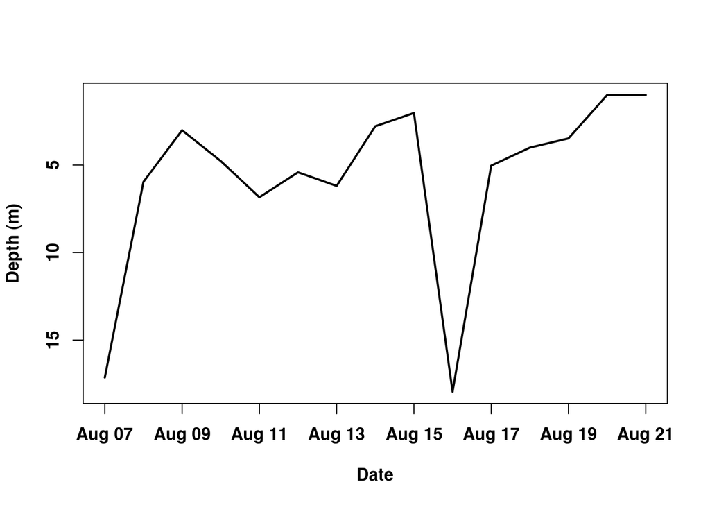

```r
# get histogram data with histogram-derived average depth and temperature values
hist_dat_1 <- read_histos(system.file("example_files/104659-Histos.csv",package="RchivalTag"))
hist_df <- hist_dat_1$TAD$DeployID.15P1019_Ptt.104659$df
View(head(hist_df))
avg1 <- hist_df$avg # avgerage depth of the tag infered from the histogram data


plot(hist_df$date, hist_df$avg, type="l", lwd=2, ylim=rev(range(hist_df$avg)), xlab="Date", ylab="Depth (m)")
```

But how accurate is this estimation? We can check this with time series data:

### Cross validating the accuracy of behavioral metrics with depth time series data:

RchivalTag comes with it’s own functions to read time series data (from Wildlife Comouters and LOTEK).

```r
ts_file <- system.file("example_files/104659-Series.csv",package="RchivalTag")
ts_df <- read_TS(ts_file)
head(ts_df)
```

```
##   DeployID    Ptt       date            datetime DepthSensor Source Instr Depth
## 1  15P1019 104659 2016-08-07 2016-08-07 00:00:00          NA   <NA>  <NA>    NA
## 2  15P1019 104659 2016-08-07 2016-08-07 00:05:00          NA   <NA>  <NA>    NA
## 3  15P1019 104659 2016-08-07 2016-08-07 00:10:00          NA   <NA>  <NA>    NA
## 4  15P1019 104659 2016-08-07 2016-08-07 00:15:00          NA   <NA>  <NA>    NA
## 5  15P1019 104659 2016-08-07 2016-08-07 00:20:00          NA   <NA>  <NA>    NA
## 6  15P1019 104659 2016-08-07 2016-08-07 00:25:00          NA   <NA>  <NA>    NA
##   DRange Temperature TRange
## 1     NA          NA     NA
## 2     NA          NA     NA
## 3     NA          NA     NA
## 4     NA          NA     NA
## 5     NA          NA     NA
## 6     NA          NA     NA
```

We will address time series data (plots) more in detail in the next tutorial. For the moment let’s focus on how to cross validate the accuracy of behavioral metrics with depth time series data. One approach to do so is to aggregate the data and calculate the average depth and its standard deviation.

```r
library(plyr)
metrics <- ddply(ts_df,.(DeployID, date),function(x) c(avg=mean(x$Depth,na.rm=T),SD=sd(x$Depth,na.rm=T)))
head(metrics)
```

```
##   DeployID       date       avg        SD
## 1  15P1019 2016-08-07 26.705263 59.074162
## 2  15P1019 2016-08-08 11.027778 36.541789
## 3  15P1019 2016-08-09  6.335069  4.586534
## 4  15P1019 2016-08-10  9.423611 10.582235
## 5  15P1019 2016-08-11 13.375000 18.669368
## 6  15P1019 2016-08-12 10.541667 18.856186
```

However, we can also generate histogram data from depth and temperature time series data! In this case, the average/SD-estimates are calculated directly from the time series data and not from the binned histogram data.

```r
tad_breaks <- c(0, 2, 5, 10, 20, 50, 100, 200, 300, 400, 600, 2000)
hist_dat_ts <- ts2histos(ts_df, tad_breaks = tad_breaks)
hist_ts <- hist_dat_ts$TAD$merged$df
head(hist_ts[,c("DeployID", "date","avg","SD")])
```

```
##   DeployID       date       avg        SD
## 1  15P1019 2016-08-07 26.705263 59.074162
## 2  15P1019 2016-08-08 11.027778 36.541789
## 3  15P1019 2016-08-09  6.335069  4.586534
## 4  15P1019 2016-08-10  9.423611 10.582235
## 5  15P1019 2016-08-11 13.375000 18.669368
## 6  15P1019 2016-08-12 10.541667 18.856186
```

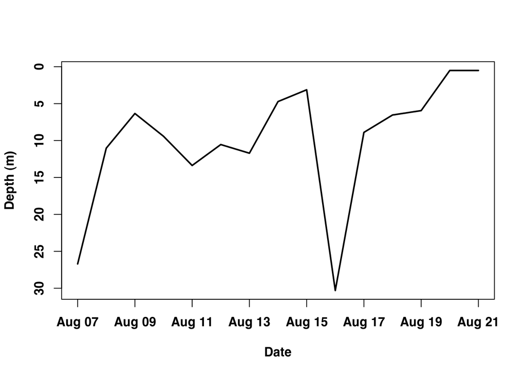

```r
plot(hist_ts$date, hist_ts$avg, type="l", lwd=2, ylim=rev(range(hist_ts$avg)), xlab="Date", ylab="Depth (m)")
```

While the two approaches (manual aggregation and transformation to histogram) yield identical results, let’s check how the average depth values from the original histogram and time series data are related:

```r
avg1 <- hist_dat_1$TAD$DeployID.15P1019_Ptt.104659$df$avg
avg2 <- hist_dat_ts$TAD$merged$df$avg
plot(avg1, avg2)
avg1-avg2
```

```
##  [1]  -9.5659122  -5.0667638  -3.3206906  -4.6526516  -6.5349209  -5.1252620
##  [7]  -5.5197247  -1.9344135  -1.0968684 -12.3537322  -3.8619386  -2.5327217
## [13]  -2.4656901   0.4895833   0.4912664
```

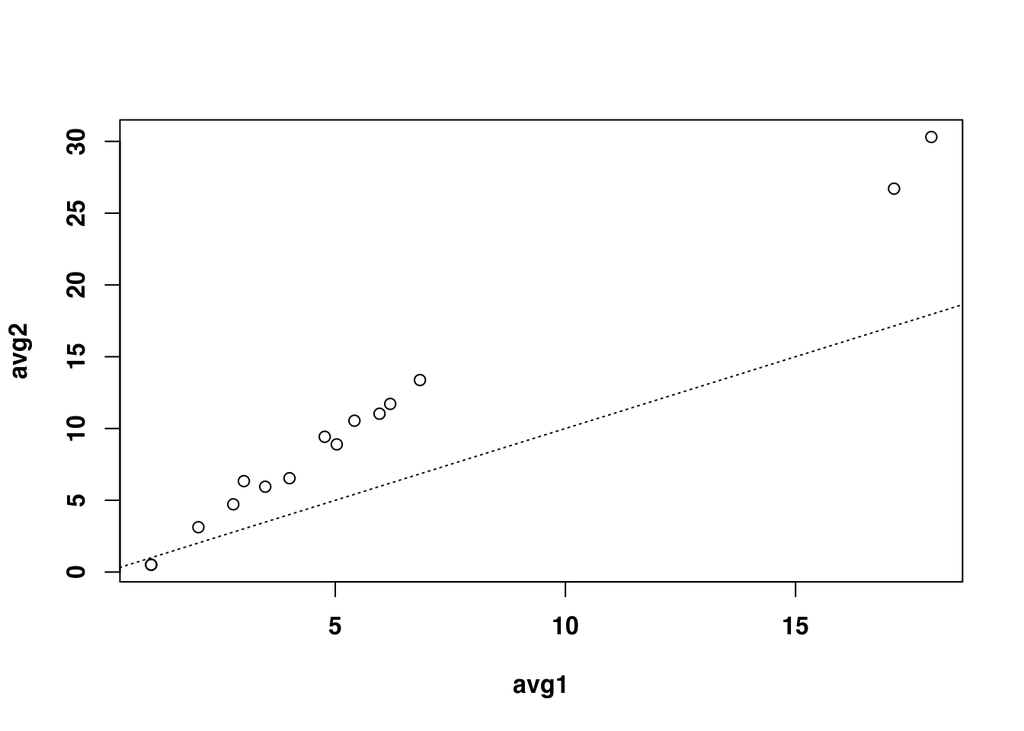

```r
abline(0,b = 1,lty="dotted")
```

```r
cor(avg1,avg2)
```

```
## [1] 0.9911037
```

```r
mean(avg1-avg2)
```

```
## [1] -4.203363
```

As we can see, the data is highly proportional and thus correlated. However, the accuracy of the average depth estimates from the original histogram data are somewhat low. It generally depends on the selection of the histogram bins and in relation to that the depth preferences of the fish species. So be cautious when using and interpreting these estimates.

## References

Bauer, Robert Klaus; Fabien; Forget, Jean-Marc; Fromentin, and Manuela Capello. 2020. “Surfacing and vertical behaviour of Atlantic bluefin tuna (Thunnus thynnus) in the Mediterranean Sea: implications for aerial surveys.” *ICES Journal of Marine Science* 77 (5): 1979–91. https://doi.org/10.1093/icesjms/fsaa083.

Bauer, Robert Klaus; Jean-Marc; Fromentin, Hervé; Demarcq, and Sylvain Bonhommeau. 2017. “Habitat use, vertical and horizontal behaviour of Atlantic bluefin tuna (Thunnus thynnus) in the Northwestern Mediterranean Sea in relation to oceanographic conditions.” *Deep-Sea Research Part II: Topical Studies in Oceanography* 141: 248–61. https://doi.org/10.1016/j.dsr2.2017.04.006.